# Data

September 5, 2018

## Notes:

- The course calendar will contain sections for each day, please follow it and match your readings to those sections
- This will also let you know when we’ll be doing labs

## An Experiment

Who likes tea?

## A Typical State

Look at the number of death penalty cases - what is typical?

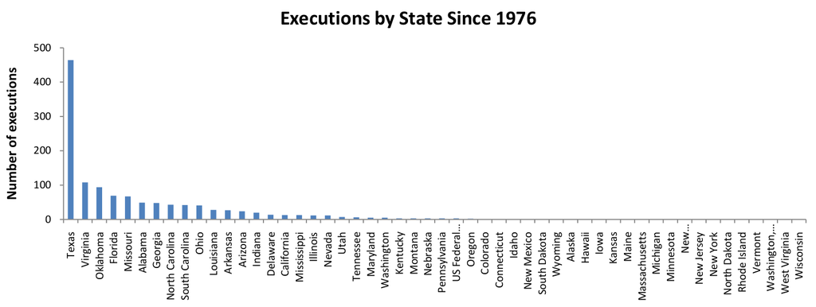

How do we measure “typical”?

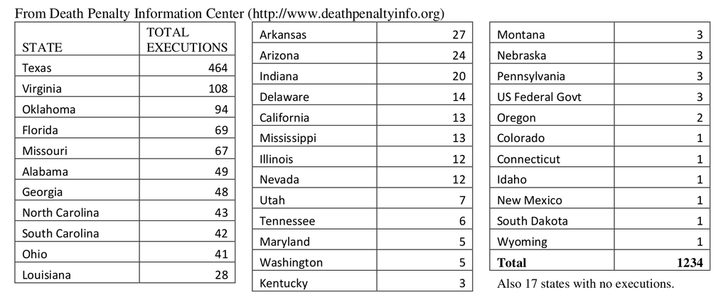

## Handedness

How do we measure a person’s handedness?

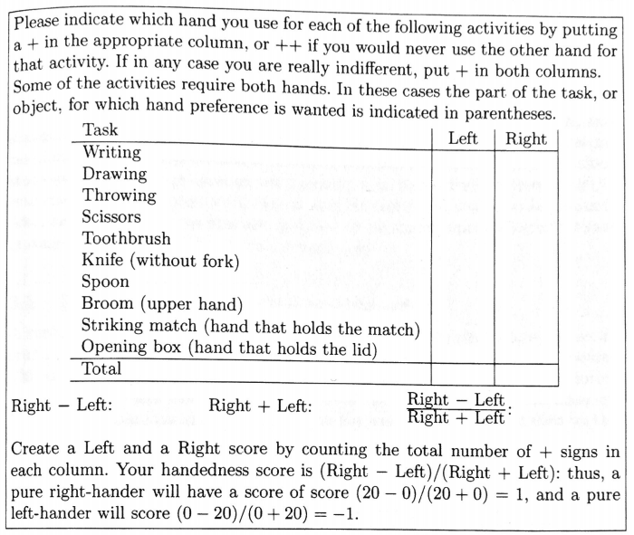

## Cases vs variables

Suppose you are conducting a test on a webpage redesign. You create two versions, randomly showing the different versions to different people. You measure how much time each person spends on the page, how many links they click on, and their operating system.

What are the:

- Cases?
- Variables?

## Cases vs variables

You are studying the effects of temperature on frog jumping height. You find 37 frogs, put them in rooms with different temperatures, and measure their jumping height as well as their leg length, sex, and approximate age.

What are the:

- Cases?
- Variables?

## Population and sample

PPSS

## PPSS

Situation - You want to estimate the average height of all IC students, so you measure 150 heights. The **sample** is:

A. The average height of the 150 student

B. The average height of all IC students

C. The 150 students that were measured

D. All IC students

## Types of variables

- Numerical vs categorical (factor)
  - Numerical: continuous vs discrete
  - Categorical: nominal vs ordinal

## Types of variables

What type of variable is:

Hair color?

Continuous

Discrete

Nominal

Ordinal

## Types of variables

What type of variable is:

Age?

Continuous

Discrete

Nominal

Ordinal

## Types of variables

What type of variable is:

The state you were born in?

Continuous

Discrete

Nominal

Ordinal

## Types of variables

What type of variable is:

The day’s high temperature?

Continuous

Discrete

Nominal

Ordinal

## Types of variables

What type of variable is:

A Likert scale?

Continuous

Discrete

Nominal

Ordinal

## Types of variables

What type of variable is:

Telephone number?

Continuous

Discrete

Nominal

Ordinal

## Data matrices (data frames)

How should we structure data so a computer can interpret it?